# Uncertainty in quantitative health impact modelling

Christopher Jackson  
MRC Biostatistics Unit, University of Cambridge

# !!WORK IN PROGRESS!!

# Uncertainty in HIA models: Summary of lecture

- Parametric models — definitions
- Quantifying parameter uncertainty using *probability distributions*
- Questions we can answer better by quantifying uncertainty
  - *Uncertainty* and *sensitivity analysis* of model outputs
  - *Value of Information* (VoI) analysis

# Quantitative models

Models approximate process that generates some output of interest, helping to inform decision-making.

- inputs: travel data, air pollution, physical activity, injuries, + scenarios of change
- outputs: population health (and changes under scenarios)

These generally involve **parameters**. What are these?

# Parametric models

Model input parameters: examples

- background exposure [e.g. PM2.5, PA] in an area
- relative risk for [health outcome] given [change in PA/AP exposure]

These are **representations of knowledge** about a population.

We can usually conceive parameters as *summaries* of individual quantities over a large/infinite “population”.

Parameters $\rightarrow$ model outputs:

- In public health, usually interested in summaries over a population (or contrasts between sub-populations)

# Parameter uncertainty

Knowledge is often uncertain $\rightarrow$

- parameters are uncertain
- conclusions from models are uncertain

# Individual variability versus uncertainty about knowledge

Example parameters, for some population

- Background exposure to PM2.5.
- Risk of death within one year.

We may be sure about the values of these. Even so…

- Exact exposures will be different for each individual
- Some individuals will die within a year, some won’t

But we may be uncertain about the parameter values.

**Individual variability can never be removed, but parameter uncertainty can be reduced with better knowledge**

# Parameters are generally uncertain

Two broad reasons for parameter uncertainty

1. summary of a limited population
2. population is different from the one we want
   - Discuss examples of this

Models are also uncertain (“structural” uncertainty)

- “all models are wrong, but some are useful”
- we won’t go into this - ideally add more parameters for uncertain things - see briefly later

# Why does uncertainty matter?

We’ve built best model we can. Just report our “best estimate” to the decision maker?

- Decision makers need good evidence to change practice — models should indicate strength of evidence for result
- What about the future - we may be able to get better evidence - what research should be done?

Here we will cover **quantitative methods** for assessing uncertainty. In particular, **probabilistic** methods.

- though there is a broader field of appraising evidence, engaging with stakeholders or experts etc…

## Questions relevant to uncertainty quantification

**Uncertainty analysis**: about *strength of evidence*

- What range of outputs are plausible, given current evidence?
- Which parameters are most uncertain (most influence the uncertainty in the outputs)

**Sensitivity analysis**: *“what if…”*

- What if parameter took the value $b$ instead of $a$ — how would the output change?

**Value of Information analysis**

- How much would the model **improve** if we got better information? on some parameter?

# How to quantify uncertainty

Two broad approaches

1. Statistical analyses of data (your own, or published analyses) giving **point** and **interval** estimates or standard errors
2. Judgements (informal or from structured elictation), e.g.
- **point estimate** (best guess) for parameter value
- **credible interval** e.g. “I judge that the parameter is between $a$ and $b$, with 95% confidence”

Our goal in each case is to obtain **probability distributions** for parameters

- powerful tool for uncertainty and sensitivity analysis

# Probability distributions

A **full probability distribution**

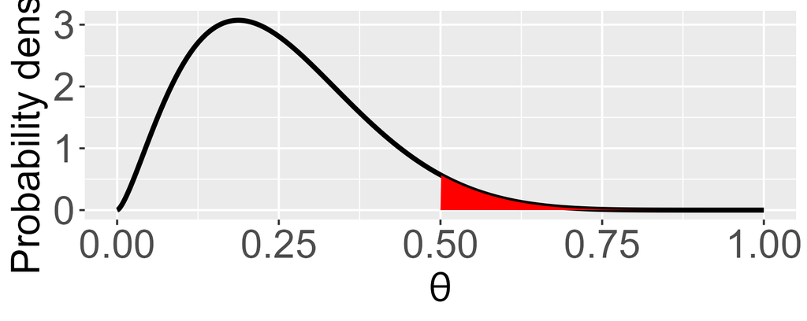

For any pair of values $(a,b)$, we can deduce probability(parameter between $a$ and $b$)

# Statistical analyses: Bayesian methods

Statistical analyses of observed data can be Bayesian or frequentist

In either, data assumed to come from models with parameters…

- e.g. number of injuries in (area,time) from Poisson with rate $\lambda$.
- **Bayesian methods** based around quantifying parameter uncertainty with probability.
- **Prior distribution** combined with study data $\rightarrow$ **posterior** distribution.

Prior distribution dominates if data are weak. No data: rely on prior judgement

# Statistical analyses: frequentist methods

- Construct “estimators” of parameters.
- Uncertainty quantified by imagining repeated samples from a population
  - “Standard error”: SD of estimates over repeated sampling.
  - 95% confidence interval: contains true value in 95% of repeated samples.
- Agrees with Bayesian estimates (posterior mean, standard deviation, credible interval) if prior is weak and data are large.
- Normal(mean, standard error). positive on log scale

If data are weak, Bayesian methods more helpful, since they allow background information as the prior

# Examples of judgements

# Distributions from credible intervals

Different distributions for quantities with different ranges…

# Normal distribution

95 percent credible interval equals mean pm 2 SDs

Width of CI is four standard deviations

Symmetry.

Transform log quantity then put normal on it

# Beta distribution

Two parameters - many ways to do it

Easiest to elicit 4 SD and derive SD. Works if symmetric

Or moment matching - demo software. Example for skewed/lo/hi

Revise and respecify limits if unsure. Mean vs mode, median. Limits may not be certain

# Practical - quantifying uncertainty around parameters

# Doing uncertainty analysis: Monte Carlo simulation

For each $i = 1, 2, \ldots N$ (enough to give precise summaries)

1. Simulate parameters $X_i$ from their uncertainty distributions
2. Compute the model output $Y_i = g(X_i)$

Summarise the sample to give e.g.

- a credible interval for the outputs
- probability that e.g. number of deaths $>$ [important value]

# Technical point - uncertainty affects “best estimate” in nonlinear models

Given a model with inputs $X$ and outputs $Y = g(X)$, where $g()$ is some mathematical function.

Inputs $X$ are uncertain, with expected values $E(X)$.

What is the expected value of $Y$? Can we just plug in the best estimates of the inputs $g(E(X)$?

$E(Y)$ is only equal to $g(E(x))$ if the function $g()$ is **linear**:

$$g(E(x)) = g((X_1 + \ldots + X_n)/n) =$$
(if $g()$ linear…)

$$(g(X_1) + \ldots + g(X_n)) / n = E(g(X)) = E(Y)$$

Most realistic models are **non-linear*: need Monte Carlo simulation to get the true expectation of the output.

# One-way sensitivity analysis: probabilistic view

In standard “tornado plots” we vary one parameter at a time

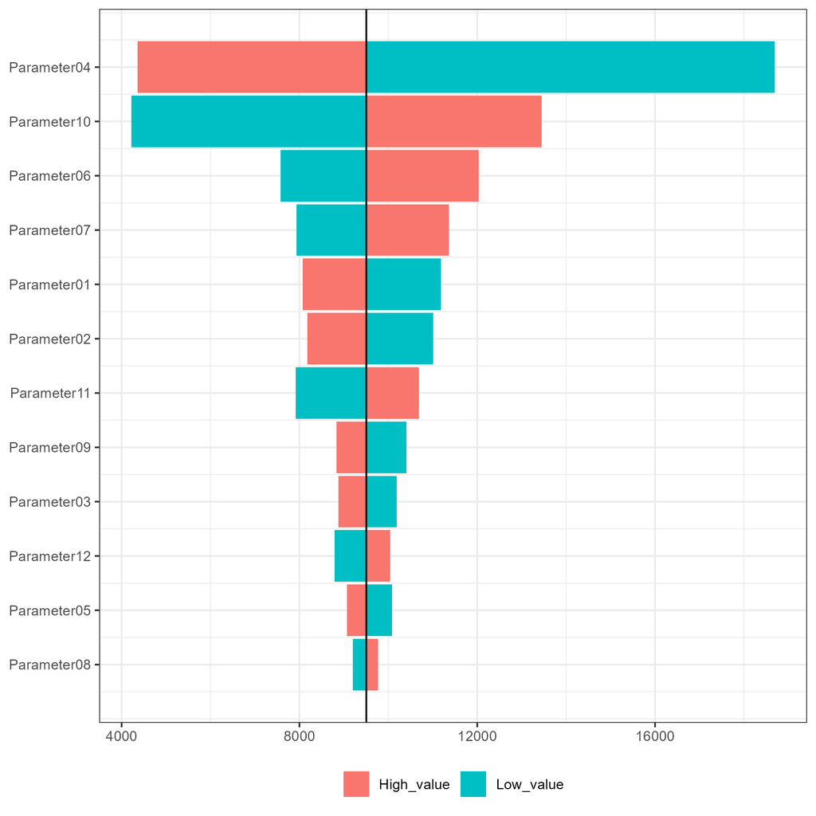

# Practical - uncertainty analysis in a model

# Value of Information

Recall

- sensitivity analysis: “what if model was a bit different”
- uncertainty analysis: “what is strength of evidence in model”

A different (related) question: “what would be the benefit of getting better information”.

**Value of Information** analysis

# Value of Information

How much more precise would x get…

if we were to learn some parameter exactly

- Expected value of partial perfect information

- Expected value of sample perfect information

Key point: we don’t know the parameter exactly, or the result of the study, when we calculate this — so we calculate an *expected* value, given what is currently known

Helps us to **set research priorities** to reduce uncertainty, and **design studies** (more advanced)

# Value of Information in terms of health economics

Value of Information analysis has mainly been used in **health economics** where we model a health policy decision and its consequences e.g. health benefits as QALYs

- Information has value $\rightarrow$ reduces uncertainty $\rightarrow$ better informed policy making $\rightarrow$ health benefits
- Used a lot in “health technology assessment”, seldom in health impact modelling, where models used more for scenarios than policies

So why talk about “value”, if we don’t model the policy?

# Precision as value

Define value as “precision of estimate”

- More precise estimates assumed to ultimately lead to benefits
- Technical benefit: we can use tools to compute VoI developed for health economic decision modelling
- We can describe precision benefits of extra information, though hard to trade off formally with costs of research (willingness to pay for more precise estimates?)

# Expected value of partial perfect information

Also called the “main effect” in computer model sensitivity analysis literature

Formal definition - expected reduction in variance

# Computing the EVPPI

Regression modelling

Splines (black box)

# EVPPI for more than one parameter at once

Multiple regression models

Recommend “earth” method

# Presenting conclusions of EVPPI analysis

Tornado-like plots, with grouped parameters

# Practical session

… Use of “voi” package

# Advanced topics

Pointers to resources to learn more about

- VoI in decision models [ book but HTA-focused ]
- Expected value of sample information [ note done in decision models, see book, but not HIA. ].

  Simple examples in paper and package

# Group discussion of advanced topics

What uncertainty/sensitivity questions do you want to answer in your own work?

Do you have the tools to do this?